# 대체휴일 도입에 따른 여행자 비율의 증감 여부

Minjee Jang

2018년 9월 26일

# 대체휴일 도입에 따른 여행자 비율의 증감

[figure not shown]

사진 출처: [링크](https://blog.naver.com/life_n_work/221363566332)

*선정 데이터: 국민여행실태조사:당일여행 시기(문화체육관광부)-성별, 연령별, 직업별 설날/추석, 공휴일 당일 여행자(2014-2017)

| *선정 이유: |
| --- |
| 1.대체휴일의 도입으로 늘어난 연휴 기간동안에 여행자 증감 비율을 알아본다. |
| 2.성별, 연령별, 직업별 여행자 비율을 비교하여 그 특징을 파악하고자 한다. |

- 당일여행 시기(2014~2017)

| 통계분류(1) | 통계분류(2) | 2014 |  | 2015 |  | 2016 |  | 2017 |  |
| --- | --- | --- | --- | --- | --- | --- | --- | --- | --- |
|  |  | 설날/추석 | 공휴일 | 설날/추석 | 공휴일 | 설날/추석 | 공휴일 | 설날/추석 | 공휴일 |
| 전체 | 소계 | 5.1 | 6.1 | 5 | 6.6 | 4.6 | 8.4 | 5.3 | 5.9 |

```r
"연도 설날/추석 공휴일
2014 5.1 6.1
2015 5 6.6
2016 4.6 8.4
2017 5.3 5.9"
```

```
## [1] "연도 설날/추석 공휴일\n2014 5.1 6.1\n2015 5 6.6\n2016 4.6 8.4\n2017 5.3 5.9"
```

출처: 문화체육관광부 링크

## 대체휴일의 정의와 도입

*대체휴일 공휴일과 휴일이 겹칠 경우, 평일에 쉴 수 있도록 하여 공휴일이 줄어들지 않도록 보장하는 제도. 설날·추석·어린이날에 제한된다.

*시행 효과: 향후 10년 간 공휴일이 11일 증가.

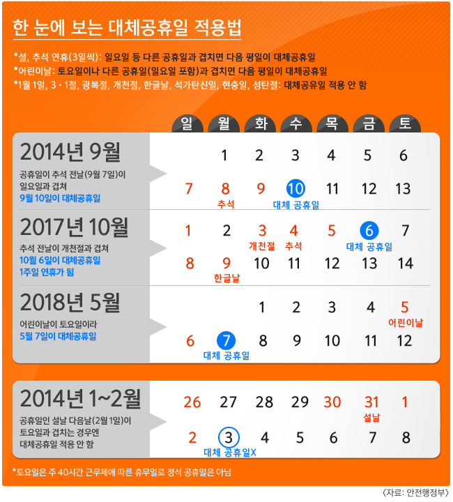

- 데이터 분석의 방향
1. 대체휴일이 도입된 사회적 배경을 알아보고

[figure not shown]

2. 대체휴일제 실시 이후 변화한 여행객 증감을 알아본다.
3. 특히나 변화폭이 큰 여행객의 성별, 연령, 직업을 알아보고 분석한다.